# Sistemos ggplot2 pagrindai

Estetinis išdėstymas

[output not shown]

[output cut: 78 more lines]

[output not shown]

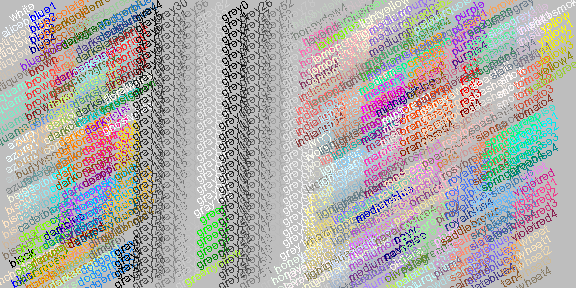

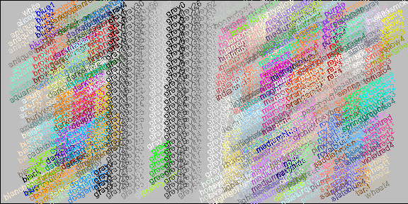

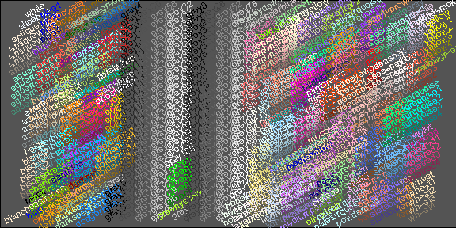

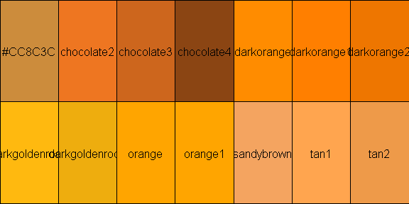

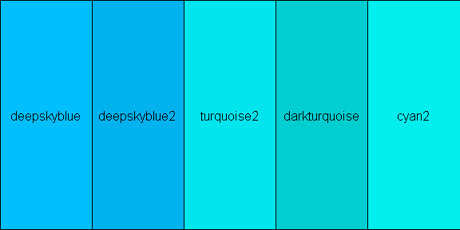

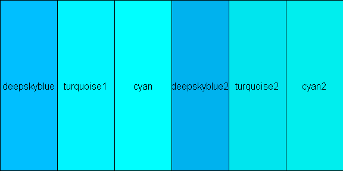

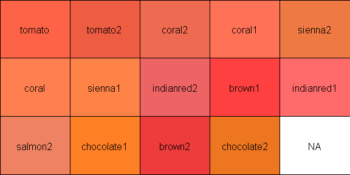

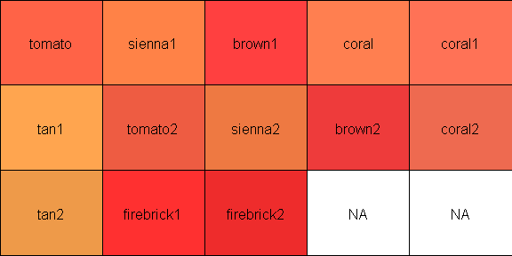

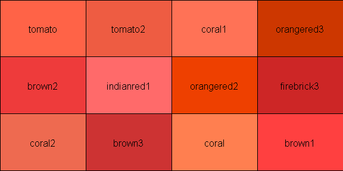

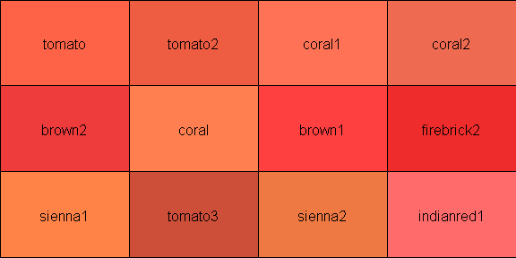

```r
demo(colors)
```

```r
library(tidyverse)
knitr::opts_chunk$set(fig.height = 3, fig.width = 6)
Sys.setlocale(locale = "Lithuanian")
```

```
[1] "LC_COLLATE=Lithuanian_Lithuania.1257;LC_CTYPE=Lithuanian_Lithuania.1257;LC_MONETARY=Lithuanian_Lithuania.1257;LC_NUMERIC=C;LC_TIME=Lithuanian_Lithuania.1257"
```

# Estetinis išdėstymas

## Klases išdėstome spalvų skalėje

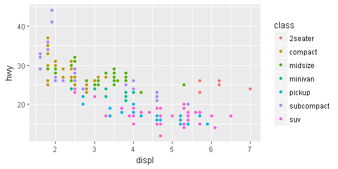

```r
 ggplot(data = mpg) +
    geom_point(mapping = aes(x = displ, y = hwy, color = class))
```

## Klases išdėstome dydžių skalėje

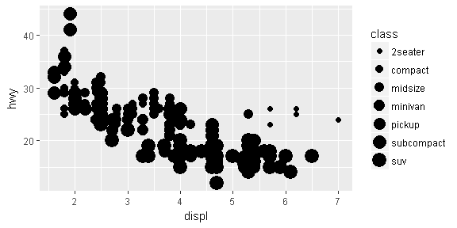

```r
ggplot(data = mpg) +
     geom_point(mapping = aes(x = displ, y = hwy, size = class))
```

## Kitos skalės išdėstymui

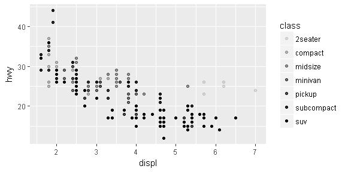

```r
# alpha – permatomumo skalė
ggplot(data = mpg) +
    geom_point(mapping = aes(x = displ, y = hwy, alpha = class))
```

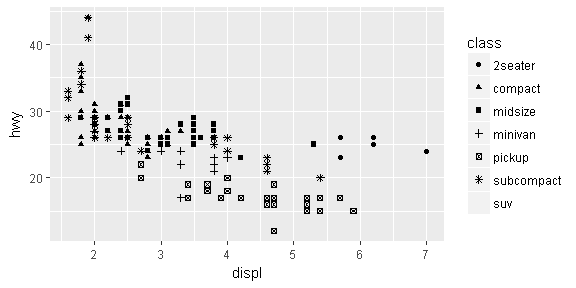

```r
# shape – formų skalė
 ggplot(data = mpg) +
   geom_point(mapping = aes(x = displ, y = hwy, shape = class))
```

## Estetinių savybių parinkimas rankiniu būdu

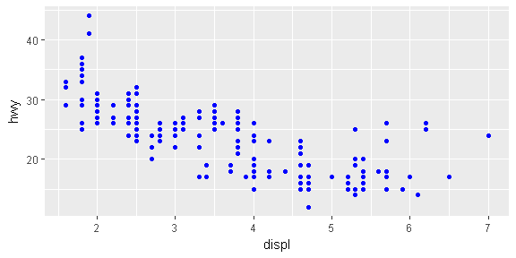

```r
ggplot(data = mpg) +
     geom_point(mapping = aes(x = displ, y = hwy), color = "blue")
```

## Kaip nurodyti spalvas?

Spalvų kodų parinkimas: https://www.w3schools.com/colors/colors_picker.asp

## Užduotys: estetinis išdėstymas

1. Kur kode klaida? Kodėl taškai ne mėlyni? Ištaisykite.

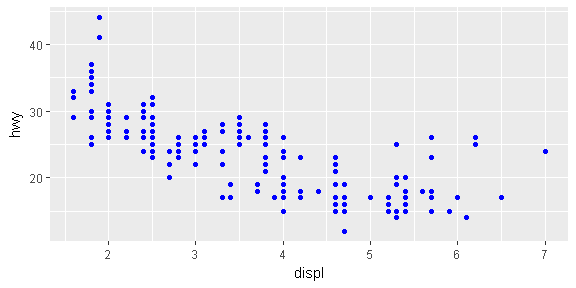

```r
ggplot(data = mpg) +
  geom_point(mapping = aes(x = displ, y = hwy), color = "blue")
```

2. Kurie lentelės `mpg` kintamieji yra kategoriniai? Kurie – tolydieji? (Užuomina: `?mpg`). Kaip tai pamatyti atspausdinus `mpg`?

```r
?mpg
```

3. Pasirinkite tolydųjį kintamąjį ir atidėkite jo reikšmes šiose skalėse: `color`, `size`, `shape`.

```r
ggplot(data = mpg) +
  geom_point(mapping = aes(x=cty, y=displ, color=cty))
```

[output not shown]

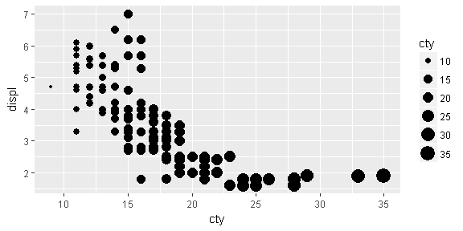

```r
ggplot(data = mpg) +
  geom_point(mapping = aes(x=cty, y=displ, size=cty))
```

4. Kuo šių estetikos elementų (`color`, `size`, `shape`) išdėstymas skiriasi, jei atidedame *kategorinį* vs. *tolydųjį* kintamąjį?

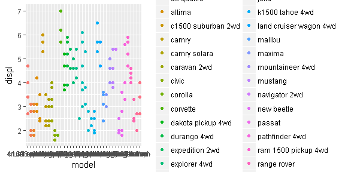

```r
ggplot(data = mpg) +
  geom_point(mapping = aes(x=model, y=displ, color=model))
```

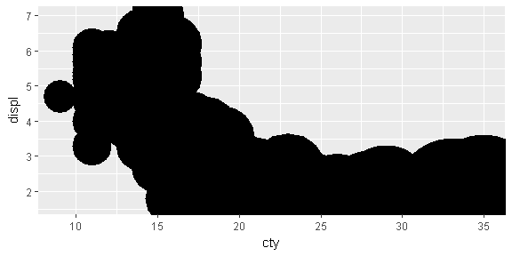

```r
ggplot(data = mpg) +
  geom_point(mapping = aes(x=cty, y=displ, stroke=cty))
```

```r
?stroke
```

```
No documentation for ‘stroke’ in specified packages and libraries:
you could try ‘??stroke’
```

5. Ką daro estetikos elementas `stroke`? Su kuriomis formomis jis veikia? (Užuomina: naudokite `geom_point`).

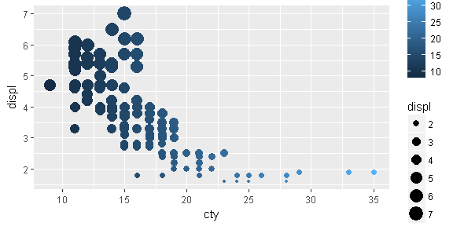

```r
ggplot(data = mpg) +
  geom_point(mapping = aes(x=cty, y=displ, color=cty, size=displ))
```

6. Kas nutinka, jei naudojate kelias skales (pvz., `color`, `size`) su keliais skirtingais kintamaisiais?

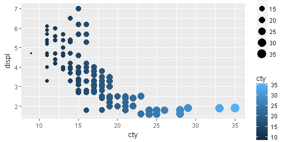

```r
ggplot(data = mpg) +
  geom_point(mapping = aes(x=cty, y=displ, color=cty, size=cty))
```

7. Kas nutinka, jei to paties kintamojo reikšmes atidedate keliose skirtingose skalėse (tarkime, `color` ir `shape`)?

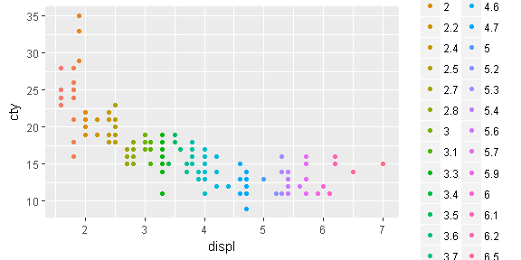

```r
ggplot(data = mpg) +
  geom_point(mapping = aes(x=displ, y=cty, color=as.factor(displ)))
```

8. Kas nutinka, jei su tam tikra skale susiejate ne konkretaus kintamojo pavadinimą (pvz., `aes(colour = displ)`), o kokį nors veiksmą su tuo kintamuoju, tarkime `aes(colour = displ < 5)`?

```r
ggplot(data = mpg) +
  geom_point(mapping = aes(x=displ, y=cty, color=as.factor(displ)))
```

[output not shown]

9. Nubraižykite grafiką ir jame rankiniu būdu parinkite spakvas naudodami:
   - spalvų pavadinimus (rašyti kabtėse);
   - šešioliktainius kodus (rašyti kabutėse);
   - spalvų numerius tarp 1 ir 8, be kabučių.